# Homework 6

Math 189 Spring 2023 Sophia Terenik Deena Pederson Gabriel Brewster

2023-05-12

# Conceptual Problems

1. Because ridge regression is a shrinkage method, we would find it useful to utilize this method when the predictor variables are highly correlated with each other. By shrinking some of the coefficients to zero, the variance decreases. This will improve reliability and stability.
2. A disadvantage of ridge regression is that all of the predictors will be included. If you are looking for less variance via a subset of predictors, ridge regression will not be useful. Another time where we would not want to use ridge regression is when relationship between predictor and response is nonlinear. Ridge regression assumes a linear relationship.

# Application Problems

3a.

```r
library(ISLR2)
library(boot)
library(glmnet)
data("Hitters")
```

```r
hitters <- subset(Hitters, select = -c(League, Division, NewLeague))
hitters <- hitters[complete.cases(hitters), ]
dim(hitters)
```

```
## [1] 263  17
```

3b.

```r
set.seed(123)
train_index <- sample(1:nrow(hitters), round(0.8 * nrow(hitters)))
train <- hitters[train_index, ]
test <- hitters[-train_index, ]
```

3c.

```r
set.seed(123)
lm_model <- lm(Salary ~ ., data = train)
summary(lm_model)
```

```
##
## Call:
## lm(formula = Salary ~ ., data = train)
##
## Residuals:
##    Min     1Q Median     3Q    Max
## -789.6 -179.9  -36.2  140.2 1915.8
##
## Coefficients:
##              Estimate Std. Error t value Pr(>|t|)
## (Intercept) 174.45475   94.28494   1.850  0.06580 .
## AtBat        -1.81331    0.76001  -2.386  0.01800 *
## Hits          5.12107    2.92236   1.752  0.08130 .
## HmRun        -5.02689    6.92000  -0.726  0.46846
## Runs         -1.14996    3.44698  -0.334  0.73903
## RBI           2.78032    3.00883   0.924  0.35661
## Walks         6.37394    2.13035   2.992  0.00313 **
## Years       -13.27666   14.31453  -0.927  0.35483
## CAtBat       -0.28595    0.15817  -1.808  0.07218 .
## CHits         0.75525    0.81379   0.928  0.35453
## CHmRun        1.57799    1.88372   0.838  0.40323
## CRuns         1.37818    0.90003   1.531  0.12735
## CRBI          0.22551    0.84573   0.267  0.79002
## CWalks       -0.63479    0.39721  -1.598  0.11165
## PutOuts       0.21738    0.08754   2.483  0.01388 *
## Assists       0.51573    0.25583   2.016  0.04520 *
## Errors       -6.85930    4.92600  -1.392  0.16538
## ---
## Signif. codes:  0 '***' 0.001 '**' 0.01 '*' 0.05 '.' 0.1 ' ' 1
##
## Residual standard error: 316.8 on 193 degrees of freedom
## Multiple R-squared:  0.5819, Adjusted R-squared:  0.5472
## F-statistic: 16.79 on 16 and 193 DF,  p-value: < 2.2e-16
```

3d.

```r
set.seed(123)
y_test <- test$Salary
y_pred <- predict(lm_model, newdata = test)
RMSE <- sqrt(mean((y_test - y_pred)^2))
RMSE
```

```
## [1] 373.854
```

3e. We expect the RMSE to be greater than the residual standard error because RMSE is the difference in the predicted vs actual values in the test dataset whereas the residual standard error is the difference in the predicted vs actual values in the training dataset.

4a.

```r
x <- model.matrix(Salary ~ ., hitters)[, -1]
y <- hitters$Salary
```

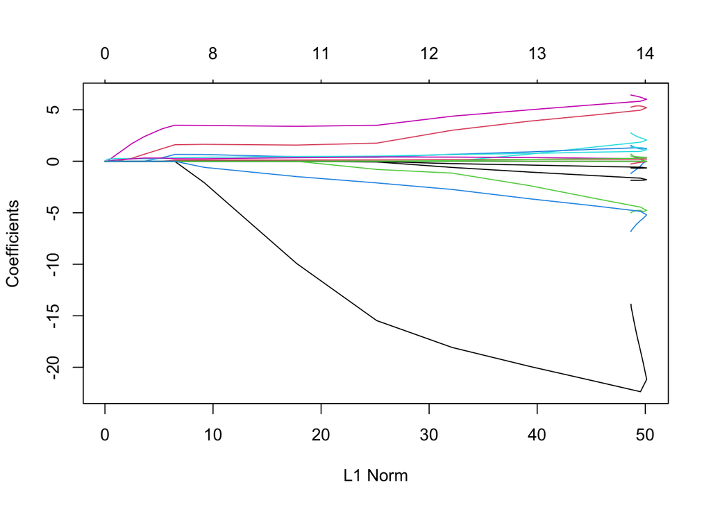

```r
grid <- 10^seq(10, -2, length = 100)
lasso.mod <- glmnet(x[train_index, ], y[train_index], alpha = 1, lambda = grid)
plot(lasso.mod)
```

4b.

```r
set.seed(123)
cv.out <- cv.glmnet(x[train_index, ], y[train_index], alpha = 1)
bestlam <- cv.out$lambda.min
out <- glmnet(x, y, alpha = 1, lambda = grid)
lasso.coef <- predict(out, type = "coefficients", s = bestlam)[1:17, ]
lasso.coef
```

```
##  (Intercept)        AtBat         Hits        HmRun         Runs          RBI
## -57.89789801   0.00000000   2.01966953   0.00000000   0.00000000   0.00000000
##        Walks        Years       CAtBat        CHits       CHmRun        CRuns
##   2.31756395   0.00000000   0.00000000   0.00000000   0.07145521   0.25558599
##         CRBI       CWalks      PutOuts      Assists       Errors
##   0.36007290   0.00000000   0.23686740   0.00000000  -0.50557651
```

When LASSO zeros out a variable, it is removing it from the model by making the coefficient estimate zero. The idea behind LASSO is that selects a subset of variables that are most important. By zeroing out coefficients, LASSO has deemed that variable to be less relevant, thus removing it from the model. 4c.

```r
bestlam <- cv.out$lambda.min
lasso.pred <- predict(lasso.mod, s = bestlam, newx = x[-train_index, ])
mean((lasso.pred - y_test)^2)
```

```
## [1] 126670.1
```

5a.

```r
grid <- 10^seq(10, -2, length = 100)
ridge.mod <- glmnet(x, y, alpha = 0, lambda = grid)
```

```r
ridge.mod$lambda[50]
```

```
## [1] 11497.57
```

5b.

```r
coef(ridge.mod)[, 50]
```

```
##   (Intercept)         AtBat          Hits         HmRun          Runs
## 404.259816123   0.036988305   0.138354280   0.524805207   0.231107356
##           RBI         Walks         Years        CAtBat         CHits
##   0.240164596   0.289952867   1.108042412   0.003132353   0.011656495
##        CHmRun         CRuns          CRBI        CWalks       PutOuts
##   0.087564108   0.023393054   0.024142296   0.025034383   0.016492859
##       Assists        Errors
##   0.002627915  -0.020458095
```

```r
sqrt(sum(coef(ridge.mod)[-1, 50]^2))
```

```
## [1] 1.314959
```

6. We think that the LASSO model is the most useful in this scenario. The general manager who is seeking to understand the most important variables to predict a players salary. This hitters dataset has many variables, some of which are less relevant than others. LASSO preforms shrinkage, effectively zeroing out less important variables. This allows the general manager to focus on the most significant variables in predicting a players salary.